# Part 1 - Regression is Function Approximation

## Galerkin Projection

At it's core, "learning" is about function approximation, i.e. give a training set $\mathbf{S} = \{(x_i,y_i)\: |\: i=1,2,\cdots,N\}$, one is interested in finding a function $y=f(x)$ that can accurately map the input data ($x_i$) to output data ($y_i$). In its most general form, there is no restriction on the type of input and output data, and given a sufficiently large training set, such a mapping may be learned by minimizing a cost function.

In Numerical Analysis, function approximation is often performed by expanding the unknown function in a known function space, i.e. we write the unknown function as a linear combination of known basis functions $\phi_i$: $$ f(x) \approx \sum_{i=1}^M w_i \phi_i(x) $$ Most often, the basis functions are chosen such that they are orthogonal w.r.t an inner product $\langle \phi_i, \phi_j \rangle = \Vert\phi_i\Vert^2\delta_{ij}$, where $\Vert\cdot\Vert = \sqrt{\langle \cdot,\cdot \rangle}$ is the norm induced by the inner product. The coefficients $w_i$ are found via projection, i.e. $$ w_i = \frac{\langle f, \phi_i\rangle}{\Vert\phi_i\Vert^2} \quad ( = \langle f, \phi_i\rangle \quad \text{if orthonormal}) $$

In Numerical Analysis (say in Finite Element Methods) this approach is referred to as the Galerkin Projection method. There is a nice geometric interpretation: given a fixed function space, the Galerkin projection gives the closest approximation of unknown function $f(x)$ using a linear combination of building blocks $\phi_i(x)$. To see, let us consider the error term $e = y - f(x)$. If we imagine that $y \in L^2(R)$, and note that $\phi_i(x)$s span a subspace $V \sub L^2(R)$, then in general $e \in L^2(R)$. Let us decompose the error into two terms, $e = e_\perp + e_V$, where $e_V \in V$ and $e_\perp \perp V$. Then the best possible approximation to $f$ is such that $e_V = 0$ which implies that $e \perp V$. In other words, the best we can possibly do is have the error term be perpendicular to subspace spanned by $\phi_i$: $$ \begin{aligned} \langle e, \phi_i \rangle &= 0, \quad \forall \:i \quad 1 \le i \le M \\ \langle y - \sum_{j=1}^M w_j \phi_j, \phi_i \rangle &= 0 \Rightarrow w_i = \langle y, \phi_i \rangle \end{aligned} $$ where we have assumed orthonormal basis for simplicity and are using $y$ and true $f(x)$ interchangeably.

Finally, we can also show that Galerkin Projection is equivalent to minimizing the 2-norm of the error. This is easy to see since if we define $$ \mathcal{L}(y, f(x)) = \frac{1}{2}\Vert e \Vert^2 = \frac{1}{2}\Vert y - f(x) \Vert^2 $$ then the coefficients are found from minimizing $\mathcal{L}$ $$ \frac{\partial \mathcal{L}}{\partial w_i} = \langle\frac{\partial \mathcal{L}}{\partial e}, \frac{\partial e}{\partial w_i}\rangle = -\langle e, \phi_i\rangle = 0 $$ which is precisely the orthogonality condition we discussed earlier based on geometric considerations.

## Least Squares

Many choices are available for the basis functions $\phi_i$ depending on the general properties the training data. For instance, a popular choice for periodic domains is the Fourier basis $\phi_i(x) = \exp(-i k_i x)$ for $x \in [0, 2\pi]$ and $\Vert \phi_i \Vert = 2\pi$. But more generally, it is possible that the chosen basis functions are not orthogonal. In such a case, it is still possible to obtain the weight coefficients albeit in a less efficient way.

To see this, lets organize the input data into column vectors $\mathbf{y} = [y_1, y_2, \cdots, y_N]^\top$ and $\mathbf{x} = [x_1, x_2, \cdots, x_N]^\top$. Next, note that we can rewrite function $\mathbf{f} = f(\mathbf{x}) = \mathbf{\Phi} \mathbf{w}$ where $\mathbf{w} = [w_1, w_2, \cdots, w_M]^\top$ is the weight vector and $\mathbf{\Phi} = [\phi_1(\mathbf{x}), \phi_2(\mathbf{x}), \cdots, \phi_M(\mathbf{x})]$ is a matrix of basis functions evaluated at points $\mathbf{x}$. Note that $\mathbf{f} \in \mathbb{R}^N$, $\mathbf{w} \in \mathbb{R}^M$, and $\mathbf{\Phi} \in \mathbb{R}^{N \times M}$. The general solution to this equation may be expressed in terms of Moore-Penrose pseudo-inverse: $$ \mathbf{w} = \mathbf{\Phi}^\dagger \mathbf{f} $$ where the pseudo-inverse can be computed from the `SVD` decomposition of $\mathbf{\Phi} = \mathbf{U} \mathbf{\Sigma} \mathbf{V}^\top$ according to $\mathbf{\Phi}^\dagger = \mathbf{V} \mathbf{\Sigma}^\dagger \mathbf{U}^\top$. Alternatively, we can again think in terms of minimizing the loss function $$ \begin{aligned} \mathcal{L} &= \frac{1}{2}\Vert f - \mathbf{\Phi} \mathbf{w} \Vert^2 \Rightarrow\\ \frac{\partial \mathcal{L}}{\partial \mathbf{w}} &= -\mathbf{\Phi}^\top \mathbf{f} + \mathbf{\Phi}^\top\mathbf{\Phi}\mathbf{w} = \mathbf{0} \Rightarrow\\ \mathbf{w} &= \underbrace{\left(\mathbf{\Phi}^\top\mathbf{\Phi}\right)^{-1} \mathbf{\Phi}^\top}_{\mathbf{\Phi}^\dagger} \mathbf{f} \end{aligned} $$ Notice if the basis functions are orthonormal, then we have $\mathbf{\Phi}^\top \mathbf{\Phi} = \mathbb{I}_{M \times M}$ and we find the same formula as before: $$ \mathbf{w} = \mathbf{\Phi}^\top \mathbf{f} = \langle \mathbf{f}, \mathbf{\Phi} \rangle $$

This approach is often called the normal equation but is less efficient to compute due to extra matrix multiplications. Nevertheless, a nice property is that now we can also add regularization according to the loss function $$ \begin{aligned} \mathcal{L} &= \frac{1}{2}\Vert f - \mathbf{\Phi} \mathbf{w} \Vert^2 + \frac{\lambda}{2}\Vert \mathbf{w}\Vert^2 \Rightarrow\\ \frac{\partial \mathcal{L}}{\partial \mathbf{w}} &= -\mathbf{\Phi}^\top \mathbf{f} + \mathbf{\Phi}^\top\mathbf{\Phi}\mathbf{w} + \lambda \mathbf{w} = \mathbf{0} \Rightarrow\\ \mathbf{w} &= \left(\mathbf{\Phi}^\top\mathbf{\Phi} + \lambda \mathbb{I}_{M \times M}\right)^{-1} \mathbf{\Phi}^\top \mathbf{f} \end{aligned} $$

## Kernel Trick

Another issue with the normal equation is the efficiency when the number of basis functions ("features" in the ML lingo) becomes large. In general, computing the weights require $\mathcal{O}(NM)$ operations: computing each weight requires $\mathcal{O}(N)$ operation for each dot product and there are $M$ weights. This is true even for orthonormal basis functions, say Fourier basis.

In Numerical Analysis, there are two ways to get around this issue. For certain basis functions, such as Fourier basis, fast methods exist to reduce the cost to $\mathcal{O}(N\log(N))$. On the other hand, in FEM we use basis functions with compact support so that computing dot products is confined to some local operation involving $n \ll N$ points. What can be done in the general case where neither options is available?

Enter the kernel trick! Here the idea is to expand the weight themselves in the basis functions, i.e. $$ \mathbf{w} = \sum_{i=1}^N \alpha_i \mathbf{\Phi}(x_i) = \mathbf{\Phi}^\top \mathbf{\alpha} $$ which, when substituted in the expansion, yields: $$ f(x) = \mathbf{\Phi}(x) \mathbf{w} = \mathbf{\Phi}(x) \mathbf{\Phi}^\top \mathbf{\alpha} = \sum_{i=1}^N \alpha_i \langle \mathbf{\Phi}(x), \mathbf{\Phi}(x_i) \rangle $$ Note that each dot product $\langle \mathbf{\Phi}(x), \mathbf{\Phi}(x_i) \rangle$ requires $\mathcal{O}(M)$ operation where $M \gg N$ could potentially be very large. The *kernel trick*, replaces these dot products in high-dimensional space with a function evaluation based on the training point $x_i$ and query point $x$, i.e. we define a kernel function $K(x_i, x)$ such that $$ \langle \mathbf{\Phi}(x), \mathbf{\Phi}(x_i) \rangle = K(x_i, x) $$ Note that the kernel function must be symmetric with respect to its arguments, i.e. $K(x_i, x) = K(x, x_i)$. A typical choice are Radial Basis Functions (RBFs) which require $K(x_i, x) = K(\Vert x_i - x\Vert)$, e.g. the Gaussian RBF: $$ K(x_i, x) = \exp(-\gamma \Vert x_i - x \Vert^2) $$ with $\gamma$ controlling the width (influence) of each point. Another popular choice is the polynomial kernel $K(x_i, x) = (1 + \langle x_i, x\rangle)^N$.

```python
import tensorflow as tf
```

```python
import numpy as np
import matplotlib.pyplot as plt
```

```python
x = np.random.rand(100)
```

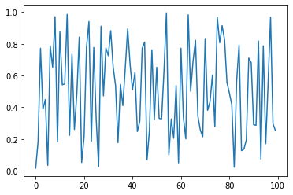

```python
plt.plot(x)
plt.show()
```